# Tarea 4

Ingrid Molina, Minor Solano & Raquel Bone

19/11/2020

En un periodo de 10 años (A) Nuestro equipo trabajó en 60 poblaciones (P) de *P. pajaritus* desde Canadá hasta Ecuador. En cada población tomamos una muestra de sangre de 10 individuos de la que extrajimos ADN genómico y amplificamos y secuenciamos los genes CMH-I para obtener el número de alelos por individuo.

Además cuantificamos 5 variables que son indicadoras de la degradación del hábitat (H) y obtuvimos las coordenadas geográficas (efecto latitudinal L) para cada población.

Nuestra **pregunta** es ¿Cómo se ve afectada la complejidad alélica de *P. pajaritus* debido a la degradación del hábitat?

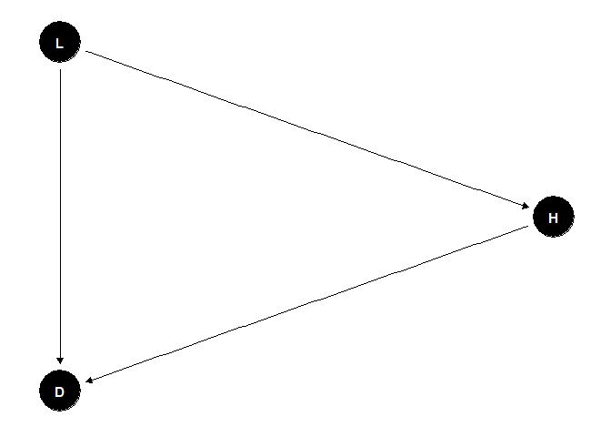

```
##   A P    L   H1    H2   H3   H4    H5  D
## 1 1 1 0.03 0.32 -1.01 0.34 2.35 -1.05 22
## 2 1 1 0.03 0.32 -1.01 0.34 2.35 -1.05 21
## 3 1 1 0.03 0.32 -1.01 0.34 2.35 -1.05 23
## 4 1 1 0.03 0.32 -1.01 0.34 2.35 -1.05 21
## 5 1 1 0.03 0.32 -1.01 0.34 2.35 -1.05 22
## 6 1 1 0.03 0.32 -1.01 0.34 2.35 -1.05 22
```

```
## 'data.frame':    600 obs. of  9 variables:
##  $ A : int  1 1 1 1 1 1 1 1 1 1 ...
##  $ P : int  1 1 1 1 1 1 1 1 1 1 ...
##  $ L : num  0.03 0.03 0.03 0.03 0.03 0.03 0.03 0.03 0.03 0.03 ...
##  $ H1: num  0.32 0.32 0.32 0.32 0.32 0.32 0.32 0.32 0.32 0.32 ...
##  $ H2: num  -1.01 -1.01 -1.01 -1.01 -1.01 -1.01 -1.01 -1.01 -1.01 -1.01 ...
##  $ H3: num  0.34 0.34 0.34 0.34 0.34 0.34 0.34 0.34 0.34 0.34 ...
##  $ H4: num  2.35 2.35 2.35 2.35 2.35 2.35 2.35 2.35 2.35 2.35 ...
##  $ H5: num  -1.05 -1.05 -1.05 -1.05 -1.05 -1.05 -1.05 -1.05 -1.05 -1.05 ...
##  $ D : int  22 21 23 21 22 22 22 24 23 21 ...
```

Según nuestro DAG el efecto latitudinal presenta un fork con la variable respuesta D y la degradación del hábitat, así que es conveniente controlar esta variable.

```r
#Cargamos librerías
library(psych)
library(lme4)
```

```r
library(ggplot2)
library(GGally)
```

### Exploramos los datos

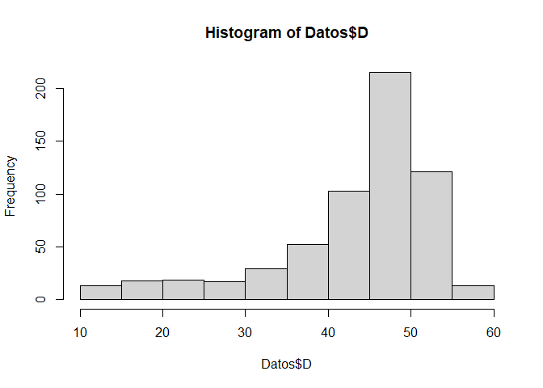

```r
#Chequeamos distribucion de datos de conteo
hist(Datos$D)
```

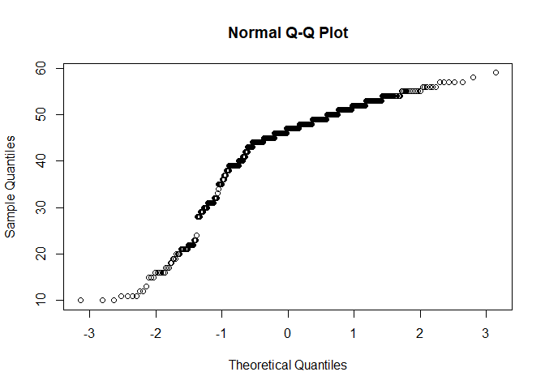

```r
qqnorm(Datos$D)
```

Al ser un conteo, nuestra variable respuesta muestra una distribución Poisson “inversa”.

Hacemos un gráfico para observar visualmente las relaciones entre las variables predictoras y la variable respuesta.

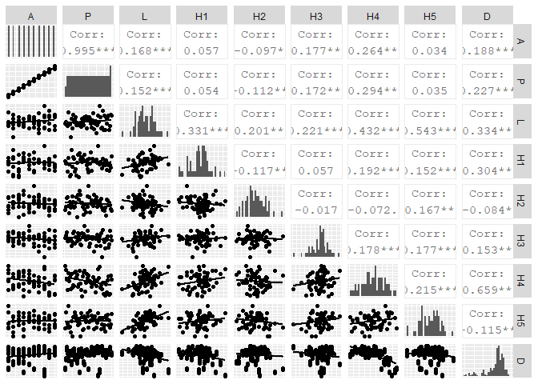

```r
ggpairs(Datos, lower = list(continuous = "smooth"),
        diag = list(continuous = "barDiag"), axisLabels = "none")
```

Las variables que tienen una mayor correlación con la diversidad alélica son: H4 (r= -0.66), latitud (r= 0.334) y H1 (r= 0.304).

### Evaluación de supuestos y modelos

```r
names(Datos)
```

```
## [1] "A"  "P"  "L"  "H1" "H2" "H3" "H4" "H5" "D"
```

```r
summary(Datos)
```

```
##        A              P               L                 H1
##  Min.   : 1.0   Min.   : 1.00   Min.   :-2.0800   Min.   :-2.230000
##  1st Qu.: 3.0   1st Qu.:15.75   1st Qu.:-0.2800   1st Qu.:-0.447500
##  Median : 5.5   Median :30.50   Median : 0.2450   Median : 0.070000
##  Mean   : 5.5   Mean   :30.50   Mean   : 0.2983   Mean   : 0.004667
##  3rd Qu.: 8.0   3rd Qu.:45.25   3rd Qu.: 1.0025   3rd Qu.: 0.587500
##  Max.   :10.0   Max.   :60.00   Max.   : 2.7400   Max.   : 2.680000
##        H2                 H3                H4                H5
##  Min.   :-2.00000   Min.   :-2.7600   Min.   :-1.8100   Min.   :-2.46000
##  1st Qu.:-0.63500   1st Qu.:-0.2375   1st Qu.:-0.4375   1st Qu.:-0.88250
##  Median :-0.13000   Median : 0.2450   Median : 0.2600   Median : 0.25500
##  Mean   :-0.09217   Mean   : 0.1792   Mean   : 0.2375   Mean   : 0.08433
##  3rd Qu.: 0.44750   3rd Qu.: 0.6225   3rd Qu.: 0.9575   3rd Qu.: 0.87500
##  Max.   : 2.49000   Max.   : 2.3400   Max.   : 2.3500   Max.   : 2.68000
##        D
##  Min.   :10.00
##  1st Qu.:41.00
##  Median :47.00
##  Mean   :43.77
##  3rd Qu.:50.00
##  Max.   :59.00
```

```r
#Inspeccionamos modelo con distribución Poisson
M1 <- glm(D ~ H1 + H2 + H3 + H4 + H5 + P + L, data = Datos, family = poisson)
summary(M1)
```

```
##
## Call:
## glm(formula = D ~ H1 + H2 + H3 + H4 + H5 + P + L, family = poisson,
##     data = Datos)
##
## Deviance Residuals:
##     Min       1Q   Median       3Q      Max
## -4.2804  -0.7547   0.2568   0.7793   2.5667
##
## Coefficients:
##               Estimate Std. Error z value Pr(>|z|)
## (Intercept)  3.7825109  0.0139986 270.206  < 2e-16 ***
## H1          -0.0465565  0.0068284  -6.818 9.23e-12 ***
## H2          -0.0394669  0.0074027  -5.331 9.75e-08 ***
## H3          -0.0053003  0.0072103  -0.735   0.4623
## H4          -0.1338991  0.0074000 -18.094  < 2e-16 ***
## H5           0.0128835  0.0070487   1.828   0.0676 .
## P            0.0005488  0.0004015   1.367   0.1716
## L           -0.0167230  0.0099852  -1.675   0.0940 .
## ---
## Signif. codes:  0 '***' 0.001 '**' 0.01 '*' 0.05 '.' 0.1 ' ' 1
##
## (Dispersion parameter for poisson family taken to be 1)
##
##     Null deviance: 1612.75  on 599  degrees of freedom
## Residual deviance:  938.42  on 592  degrees of freedom
## AIC: 4303.6
##
## Number of Fisher Scoring iterations: 4
```

```r
#Determinamos cuanto explica el modelo los datos
1 - (M1$deviance / M1$null.deviance)
```

```
## [1] 0.4181222
```

```r
#Inspeccionamos si hay sobre dispersión
resid.dev <- M1$deviance # Extraemos la deviance y los grados de libertad
resid.DF <- M1$df.residual
resid.dev / resid.DF #Si esta proporción es cercana a 1, no hay SP
```

```
## [1] 1.585175
```

El modelo explica cerca del 42% de la varianza de los datos. La proporción es cercana a 1, así que consideramos que no hay mucha sobre dispersión.

A continuación, vamos a chequear si nuestro modelo es mejor que el modelo nulo o un modelo con menos factores.

```r
#Selección de modelos
M0 <- glm(D ~ 1, data = Datos, family = poisson) #modelo nulo
M1 <- glm(D ~ H1 + H2 + H3 + H4 + H5 + P + L + A, data = Datos, family = poisson)
M2 <- glm(D ~ H2 + H3 + H4 + H5 + P + L + A, data = Datos, family = poisson)
M3 <- glm(D ~ H1 + H3 + H4 + H5 + P + L + A, data = Datos, family = poisson)
M4 <- glm(D ~ H1 + H2 + H3 + H5 + P + L+ A, data = Datos, family = poisson)
M5 <- glm(D ~ H1 + H2 + H3 + H4 + P + L+ A, data = Datos, family = poisson)

# Chequeamos AIC
AIC(M0, M1, M2, M3, M4, M5)
```

```
##    df      AIC
## M0  1 4963.934
## M1  9 4250.112
## M2  8 4298.297
## M3  8 4264.609
## M4  8 4500.540
## M5  8 4248.964
```

```r
#Los modelos M1 y M5 presentan los menores coeficientes AIC, que no son significativamente distintos
anova(M1, M5, test = "Chi")
```

```
## Analysis of Deviance Table
##
## Model 1: D ~ H1 + H2 + H3 + H4 + H5 + P + L + A
## Model 2: D ~ H1 + H2 + H3 + H4 + P + L + A
##   Resid. Df Resid. Dev Df Deviance Pr(>Chi)
## 1       591     882.93
## 2       592     883.78 -1 -0.85173   0.3561
```

Elegimos el M5 por ser mas parsimonioso.

```r
#Resumen del modelo
summary(M5)
```

```
##
## Call:
## glm(formula = D ~ H1 + H2 + H3 + H4 + P + L + A, family = poisson,
##     data = Datos)
##
## Deviance Residuals:
##     Min       1Q   Median       3Q      Max
## -3.9738  -0.5666   0.1713   0.7187   2.5863
##
## Coefficients:
##              Estimate Std. Error z value Pr(>|z|)
## (Intercept)  3.855228   0.016874 228.471  < 2e-16 ***
## H1          -0.048846   0.006831  -7.150 8.65e-13 ***
## H2          -0.030724   0.007496  -4.099 4.15e-05 ***
## H3          -0.010684   0.007228  -1.478    0.139
## H4          -0.121975   0.007607 -16.034  < 2e-16 ***
## P            0.030174   0.003916   7.705 1.31e-14 ***
## L           -0.002906   0.008770  -0.331    0.740
## A           -0.178481   0.023441  -7.614 2.66e-14 ***
## ---
## Signif. codes:  0 '***' 0.001 '**' 0.01 '*' 0.05 '.' 0.1 ' ' 1
##
## (Dispersion parameter for poisson family taken to be 1)
##
##     Null deviance: 1612.75  on 599  degrees of freedom
## Residual deviance:  883.78  on 592  degrees of freedom
## AIC: 4249
##
## Number of Fisher Scoring iterations: 4
```

```r
#Determinamos cuanto explica el modelo los datos
1 - (M5$deviance / M5$null.deviance)
```

```
## [1] 0.4520039
```

```r
#Inspeccionamos si hay sobre dispersión
resid.dev <- M5$deviance # Extraemos la deviance y los grados de libertad
resid.DF <- M5$df.residual
resid.dev / resid.DF #Si esta proporción es cercana a 1, no hay SP
```

```
## [1] 1.492874
```

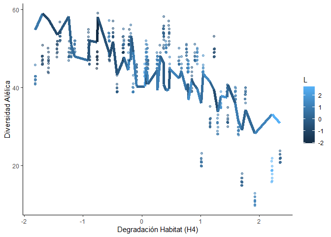

```r
#Predicción del modelo
Datos$fit <- predict(M5, type = "response")

#Ordenamos por efecto latitudinal, año y población
Datos2 <- Datos[with(Datos, order(L, A, P)), ]

#Intento de gráfico
ggplot(Datos2, aes(x = H4, y = fit, colour = L)) +
  geom_point(aes(y = D), alpha = 0.5,
             position=position_jitter(h = 0.2)) +
  geom_line(size = 1.85) +
  labs(x = "Degradación Habitat (H4)", y = "Diversidad Alélica") +
  theme_classic()
```

De acuerdo a nuestros resultados, no existe un efecto significativo latitudinal sobre la diversidad alélica, lo cual es muy interesante, pues si se registra un efecto covariable leve de la población en específico (estimado= 0.03) y con mayor peso del año que se tomaron los datos (estimado= -0.18). Encontramos que la degradación del hábitat medida a través de las variables H4, H1 y H2 tienen influencia sobre la diversidad alélica de *P. pajaritus*, siendo el mayor el de la variable H4 (estimado= -0.12).

Según nuestro modelo predictivo, se explica un 45% de los datos, y observamos la tendencia de que a mayor degradación ambiental disminuye la diversidad alélica.

Con estos resultados concluimos que es importante tomar en cuentas las variaciones anuales y en específico la degradación del hábitat H4 para predecir la diversidad alélica de *P. pajaritus*. Además, se infiere que existe otro factor determinante en la diversidad alélica que no se midió en este estudio.

**Información de la sesión**